# Statistical inference concepts of binomial distribution

statistical inference

binomial distribution

Author

Rui Yang

Published

September 21, 2024

Modified

September 21, 2024

## 1 Bernoulli distribution

In an experiment, there are only two outcomes: success $A$ ($X = 1$) and failure $\overline{A}$ ($X = 0$), and the probability of success is $p$. Such an experiment is called a Bernoulli experiment.

In a Bernoulli experiment, the number of success, denoted by $X$, is a random variable and its distribution is called a Bernoulli distribution or a two-point distribution.

Clearly, the PMF of a Bernoulli distribution is

$$p(x) = P(X = x) = \begin{cases}
p &\text{if } x = 1 \\
1 - p &\text{if } x = 0
\end{cases}$$

Then $E(X) = \sum_{i=1}^{\infty} x_i p(x_i) = 1 \times p + 0 \times (1 - p) = p$, and $Var(X) = E[(X - E(X))^2] = \sum_{i=1}^{\infty} (x_i - E(X))^2 p(x_i) = (1 - p)^2 \times p + (0 - p)^2 \times (1 - p) = p(1 - p)$.

## 2 Binomial distribution

In $n$ independent Bernoulli trials, each with the probability of success $p$, the number of success $Y$ is distributed as a binomial distribution.

The PMF of a binomial distribution is

$$p(k) = P(Y = k) = \binom{n}{k} p^k (1-p)^{n - k}, k = 0, 1, ..., n$$

Clearly, a binomial distribution can be regarded as the sum of $n$ independent Bernoulli distributions, i.e., $Y = X_1 + \cdots + X_n$. Then, by using the arithmetic properties of expectation and variance, we have $E(Y) = np$ and $Var(Y) = np(1 - p)$.

Due to $Y$ is the sum of $n$ independent Bernoulli random variables, we have $Y\ \ \widetilde{\text{approx}}\ \ N(np, np(1 - p))$ as $n \to \infty$ based on the central limit theorem. We also have $\frac{Y}{n}\ \ \widetilde{\text{approx}}\ \ N(p, \frac{p(1 - p)}{n})$.

## 3 Introduction

Assume that we repeat a Bernoulli trial $n$ times, each of which has the same success probability $p$, and that the number of successes is $n_s$. Then, the random variable (denoted by $X_i$, with value $1$ (success) or $0$ (failure)) in the $i$th Bernoulli trial is distributed as a Bernoulli distribution with the probability of success $p$. According to the central limit theorem, the random variable $Y_n = \sum_{i=1}^{n} X_i$ distributed as a Binomial distribution with parameters $n$ and $p$ can be approximately distributed as a normal distribution (i.e. $Y_n \sim N(np, np(1-p))$). And similarly, we have $\hat{p} = \frac{Y_n}{n} \sim N(p, \frac{p(1-p)}{n})$.

## 4 Point estimates of $p$

### 4.1 Method of Moments (MM)

$$\begin{align}
\hat{m} &= \frac{1}{n} \sum_{i=1}^{n} X_i = \frac{k}{n} \\
m &= p \\
\hat{m} &= m
\end{align}$$

Hence

$$p = \frac{k}{n}$$

### 4.2 Maximum likelihood estimate (MLE)

For given $n$ and $k$, we need to find a $p$ to maximize the likelihood function (to make the likelihood of observing $k$ successes among $n$ experiments in total maximized):

$$\begin{align}
L(p) &= \binom{n}{k} p^k (1 - p)^{n - k} \\
\log{L(p)} &= \log{\binom{n}{k} + k\log{p} + (n - k)\log{(1 - p)}} \\
\frac{d\log{L(p)}}{dp} &= \frac{k}{p} - \frac{n - k}{1 - p} = 0 \\
p &= \frac{k}{n}
\end{align}$$

There is a point $p = \frac{k}{n}$ that maximizes $L(p)$.

## 5 Confidence intervals of $p$

[figure not shown]

We can use the standard logistic curve to check the overshoot and zero-width of the normal confidence interval:

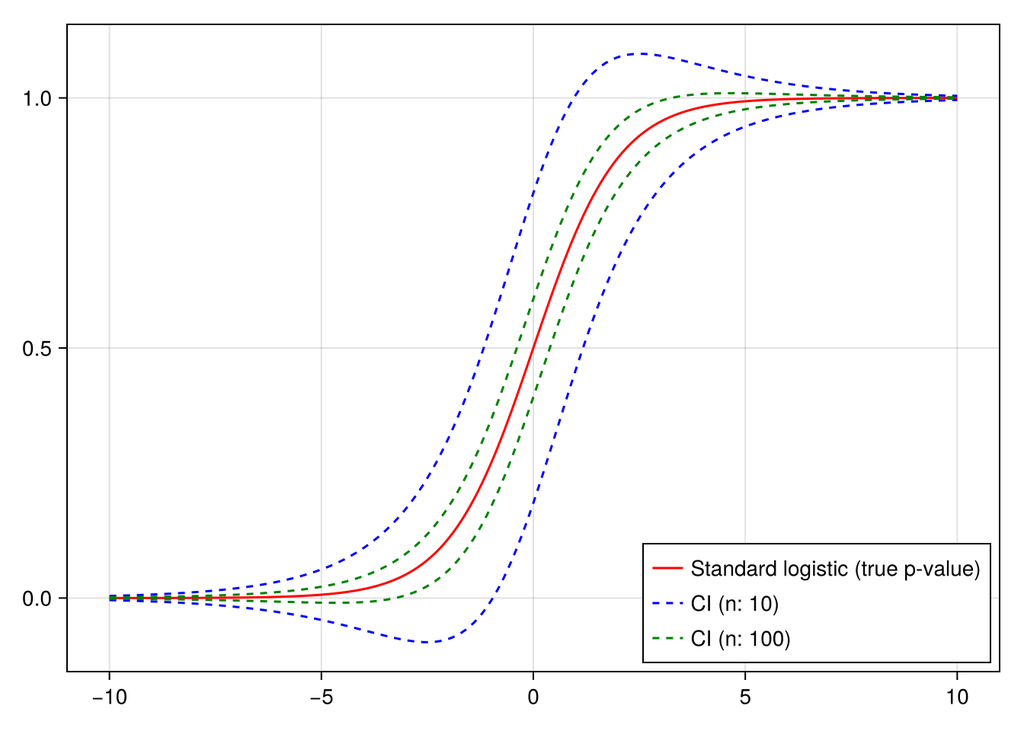

```julia
using CairoMakie, Statistics, Distributions

# the standard logistic curve can be regareded as a CDF
# for each p-value, given specific n, we can calculate its normal confidence interval
# we can easily see that there is a overshoot or zero-width situation
# when p → 0 or 1
function standard_logistic(x)
    1 / (1 + exp(-x))
end

xGrid = -10:0.1:10
pVals = standard_logistic.(xGrid)

alpha = 0.05
z = quantile(Normal(), 1 - alpha / 2)

ns = [10, 100]
colors = [:blue, :green]

fig, ax = lines(xGrid, pVals; color=:red, label="Standard logistic (true p-value)")
for i in 1:length(ns)
    pValLowerCIs = similar(pVals)
    pValUpperCIs = similar(pVals)

    @. pValLowerCIs = pVals - z * sqrt(pVals * (1 - pVals) / ns[i])
    @. pValUpperCIs = pVals + z * sqrt(pVals * (1 - pVals) / ns[i])

    lines!(ax, xGrid, pValLowerCIs; color=colors[i], linestyle=:dash, label=string("CI (n: ", ns[i], ")"))
    lines!(ax, xGrid, pValUpperCIs; color=colors[i], linestyle=:dash)
end
axislegend(ax; position=:rb)
fig
```